# dexamethasone

AndreyPovaliy

2023-11-29

Федеральное государственное бюджетное образовательное учреждение высшего образования «Санкт-Петербургский государственный университет» Клиника высоких медицинских технологий им. Н. И. Пирогова

Травматологическое отделение №2

# Протокол клиического исследования

## Тема “Влияние периоперационной дозы дексаметазона на послеоперационный болевой синдром”

Специальность: 3.1.8 – травматология и ортопедия

Срок выполнения: 2024 гг.

Исполнитель: врач травматолог-ортопед отделения травматологии №2, Клименко В.С.

Санкт-Петербург, 2023 г.

## 1. Актуальность

Операция тотального эндопротезированиея коленного сустава (ТЭПКС) является одной из наиболее часто выполняемых и экономически эффективных операций на опорно-двигательном аппарате. На протяжении последних нескольких десятилетий потребность в этой процедуре продолжает возрастать во всем мире [1]. ТЭПКС стало золотым стандартом лечения пациентов с терминальными стадиями артроза коленного сустава [2]. В тоже время нельзя не отметить, что боль остается серьезной проблемой в раннем послеоперационном периоде [3]. Это, наряду с послеоперационным отеком и мышечной слабостью, препятствует ранней мобилизации и реабилитации пациентов [4]. Несмотря на применение мультимодальной аналгезии, включающей НПВП, парацетамол, местную инфильтрационную анестезию, выраженность болевых ощущений зачастую сохраняется на среднем или высоком уровне после операции[5].

Кортикостероиды являются мощными противовоспалительными препаратами и играют физиологическую роль в подавлении медиаторов воспаления. Они доказали свою эффективность в послеоперационном обезболивании после различных видов операций [6–9].

В последние годы были проведены метаанализы, оценивающие эффективность дексаметазона для контроля боли при тотальном эндопротезировании коленного или тазобедренного сустава [[10]; [11]; [12]; [13]; [14];]. Несмотря на то, что исследования явно показывают преимущество использования периоперационного использования дексаметатазона при выявленной безопасности, авторы указывают, что по-прежнему необходимы исследования изучения взаимосвязи между осложнениями и реакцией на дозу, чтобы сделать окончательный вывод.

Существуют исследования которые указывают на оптимальную дозу, которая принята на сегодняшний день 4-8 мг [15], однако проблему применения накотических средств в раннем послеоперационном периоде эта доза не решеает и эффект более высоких доз глюкокортикоидов является перспективным направлением [16,17], осебенно в условиях контроля работы с наркотическими обезболивающими, политикой снижения потребления подобных средств и вытекающее из этого направление персонализированную опиоидсберегающий контроль боли у пациентов [18] .

## 2. Степень разработанности проблемы

Вопрос увеличения дозы является дискутабельным и нами был проведен анализ литературы посвященной повешенных доз.

Nielsen, Niklas I et al. в 2022 году [16] провели исследование в котором сравнивались различные высокие дозы (1,0 и 0,3 мг/кг ). По сравнению с предоперационным введением дексаметазона в дозе 0,3 мг/кг внутривенно, дексаметазон в дозе 1 мг/кг уменьшал боль через 24 часа после ТЭПКС и улучшал восстановление у пациентов с высокой реакцией на боль без видимых побочных эффектов.

Chan, Timmy Chi Wing et al. в 2020 году [19] сравнивали группы пациентов с увеличенной ойзой 16мг, нормальной дозой 8 мг и плацебо. Прием дексаметазона в дозе 16 мг перед ТЭПКС привел к уменьшению послеоперационной боли, меньшему потреблению навркотических анальгетиков, увеличению силы четырехглавой мышцы и улучшению общего качества восстановления после операции.

В нашем лечебном учреждении принят анестезиологический протокол, предполагающий введение 8 мг дексаметазона, при выполнении эндопротезирования коленного сустава, это соответствует общепринято практике [15].

Опираясь на представленные выше метаанализы, а также информации из более поздних клинических исследований [16,19], в этой работе предполагается оценить эффективность повышенных дозировок дексаметазона: 0,3 мг/кг на уровень послеоперационного болевого синдрома, без увеличения побочных эффектов, по сравнению с стандартной дозой 8 мг [15] .

## 3. Цель исследования

Провести клиническую оценку эффективности интраоперационных повышенных дозировок дексаметазона: 0,3 мг/кг на уровень послеоперационного болевого синдрома, без увеличения побочных эффектов, по сравнению с стандартной дозой 8 мг

## 4. Предмет исследования

1. Болевой синдром в первые сутки после ТЭПКС, определяемое визуальными шкалами
2. Ранее восстановление пациента после ТЭПКС, определяемое в объема движений

## 5. Объект исследования

Пациенты перенесшие первичное тотальное эндопротезирование коленного сустава

## 6. Методы исследования

Моноцентровое проспективное рандомизированное клиническое исследование планируется провести в период с января 2024 года по декабрь 2024 года. Планируется участие пациентов с диагнозом: «Идиопатический гонартроз III стадии»

Планируемое количество пациентов 92 человека. Расчет количества пациентов проводился методом определения мощности пропорций по относительному показателю боли, выраженному в процентах (%) в уже проведенном в 2021 исследовании Nielsen N.I. и коллег [16], а именно был взят показатель боль при ходьбе через 24 часа после операции уменьшилась (высокая доза по сравнению со средней дозой, 49% против 79%; P<0,01) [16].

**Критерии включения пациентов:**

- Мужчины и женщины старше 18 лет, нуждающиеся в первичном эндопротезировании коленного сустава.
- Пациенты с установленным диагнозом идиопатический гонартроз 3 ст. (по Н.В. Косинской) с фронтальной варусной деформацией в области коленного сустава не более 15 град.
- Со сгибательной контрактурой не более 15 град.
- Возможность сгибания в коленном суставе не менее 100 град.
- Пациенты, не имеющие противопоказаний к проведению оперативного вмешательства по сопутствующим заболеваниям, а также способные выполнять все рекомендации и указания в рамках данного исследования.

**Регистрируемые данные:**

- Фамилия Имя Отчество
- Возраст
- Рост
- Вес
- Пол
- ИМТ
- Сопутсвующие заболевани (в частности нарушения толерантности к глюкозе)
- Длительность госпитализации
- Время жгута
- Время операции

*Клинические методы исследования:*

Лабораторные:

- Клинический анализ крови с учетом уровня гемоглобина до операции и на 2-е после операции. Регистрация гемоглобина будет проводиться количественно и качественно. Для количественной оценки результат будет регистрироваться в г/л, с точностью 1 г/л. Качественная оценка будет проводится по 4 степеням анемии. Нормальным содержанием гемоглобина в крови человека будет считаться: у мужчин — 130—160 г/л , у женщин — 120—160 г/л. По гемоглобину будут определены 4 степени анемии [20]: I – гемоглобин менее 120 г/л, но более 100 г/л; II – значение гемоглобина крови находится в пределах от 80 до 99 г/л; III – уровень гемоглобина составляет 65-79 г/л; IV – гемоглобин крови менее 65 г/л.
- Биохимический панализ крови с учетом СРБ до операции 1,2 день после [21].
- Биохимический панализ крови с учетом глюкозы в крови на 6 часов и 24 часа

Статистические методы: сбор данных будет осуществляться при помощи программ Exel [22]. Статистическая оценка будет проводиться с помощью встроенных пакетов программы Statistica 12 [23]. Для параметрических данных будет определяться нормальность распределения с помощью построения QQ-plot графика[24]. При нормально распределении для независимых выборок будет применяться t-тест Стьюдента, при ненормальном распределении U-тест Манна-Уитни. Для определения категориальных данным будет применяться либо Хи-кадрат Пиросона или точный критерий Фишера в зависимости требований, предъявляемых к данным[25].

## 7. Средства исследования:

- Форма оценки болевого синдрома ВАШ
- Форма оценки осложнений шкала Dindo-Clavien
- Набор хирургического инструментария, расходного материала и силового и специализированного оборудования

## 8. Объем планируемых исследований

Основные этапы проведения исследования представлены на рисунке №1.

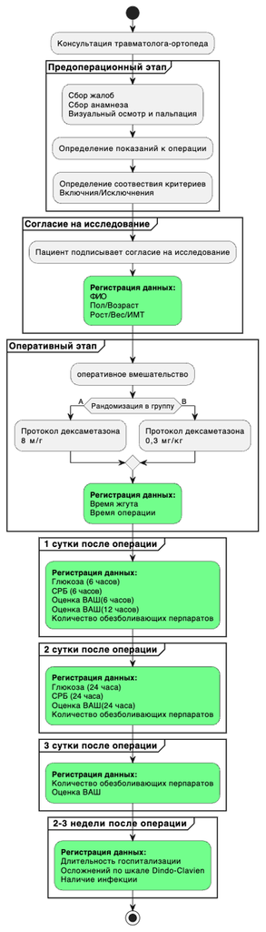

Рисунок №1. Объем планируемых исследований

## 10. Научная новизна

На сегодняшний день существует мало исследований посвященным повышенным лозам дексаметазона, только в 2022 Nielsen, Niklas I et al. в 2022 году [16] провели исследование в котором сравнивались различные высокие дозы (1,0 и 0,3 мг/кг ), однако представленное исследование оценивает выбор дозировки повышенной дозы. Мы же в нашем исследовании планируем рассмотреть эффективность. ибезопасность повышенной дозы дексаметазона, так как на сегодняшний день однозначных данных на этот счет нет.

## 11. Ожидаемые результаты

Согласно данным изкченной литерватуры ожидается более значимый результат в пользу группы B по покзателям боли, потреблению наркотических обезболивающих. Отсутвие разницы между группами по показателям глюкоза в крови, СРБ, осложненгия и наличие послеоперационной инфекции.

## 12. Возможная область применения результатов исследования

Результаты могут быть использованы в практической деятельности врачей травматологов-ортопедов в условиях стационара и учебно-педагогическом процессе студентов и врачей.

## 13. Формы внедрения:

Публикация статьи в научном журнале, издании методических пособий для практикующих врачей, выступление на российских конгрессах, в том числе с международным участием. Также результаты настоящего исследования являются частью диссертационного исследования Клименко В.С. по специальности “3.1.8 – травматология и ортопедия”.

## 14. Практическая значимость

Формулирование рекомендации - повешенная доза интраоперационного ввдения декаметазона 0,3 мг/кг эффективно влияет на уровень послеоперационного болевого синдрома при сопостовимой безопасности по сравнения с принятыми дозами.

## 15. Охраноспособность

Планируемая тема является охраноспособной.

## 16. Приложение

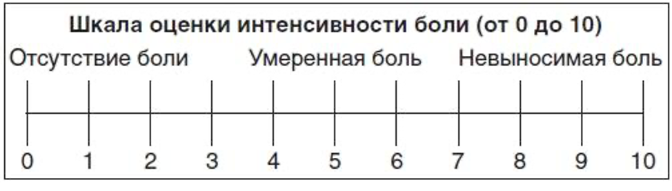

Шкала ВАШ

## 17. Список сокращений

ТЭПКС – тотальное эндопротезирование коленного сустава

Hb – гемоглобин

ОД - объема движений

ВАШ- визуальная аналоговая шкала

СРБ - С-реактивный белок

CRediT - Contributor Roles Taxonomy

## 18. Список используемой литературы

1.

Price AJ, Alvand A, Troelsen A, et al. Knee replacement. *The Lancet*. 2018;392(10158):1672-1682. doi:10.1016/s0140-6736(18)32344-4

2.

Sharma L. Osteoarthritis of the knee. *New England Journal of Medicine*. 2021;384(1):51-59.

3.

Aasvang EK, Luna IE, Kehlet H. Challenges in postdischarge function and recovery: the case of fast-track hip and knee arthroplasty. *British Journal of Anaesthesia*. 2015;115(6):861-866. doi:10.1093/bja/aev257

4.

Petersen PB, Kehlet H, Jørgensen CC, et al. Improvement in fast-track hip and knee arthroplasty: a prospective multicentre study of 36,935 procedures from 2010 to 2017. *Scientific Reports*. 2020;10(1). doi:10.1038/s41598-020-77127-6

5.

Webb CAJ, Madison S, Goodman SB, Mariano ER, Horn JL. Perioperative Pain Management for Total Knee Arthroplasty: Need More Focus on the Forest and Less on the Trees. *Anesthesiology*. 2018;128(2):420-421. doi:10.1097/aln.0000000000001992

6.

Salerno A, Hermann R. Efficacy and Safety of Steroid Use for Postoperative Pain Relief. *The Journal of Bone & Joint Surgery*. 2006;88(6):1361-1372. doi:10.2106/jbjs.d.03018

7.

Kjetil H, Sem TK, Ellen S, Johan R. The Prolonged Postoperative Analgesic Effect When Dexamethasone Is Added to a Nonsteroidal Antiinflammatory Drug (Rofecoxib) Before Breast Surgery. *Anesthesia & Analgesia*. 2007;105(2):481-486. doi:10.1213/01.ane.0000267261.61444.69

8.

Romundstad L, Breivik H, Niemi G, Helle A, Stubhaug A. Methylprednisolone intravenously 1day after surgery has sustained analgesic and opioid-sparing effects. *Acta Anaesthesiologica Scandinavica*. 2004;48(10):1223-1231. doi:10.1111/j.1399-6576.2004.00480.x

9.

Bisgaard T, Klarskov B, Kehlet H, Rosenberg J. Preoperative Dexamethasone Improves Surgical Outcome After Laparoscopic Cholecystectomy. *Annals of Surgery*. 2003;238(5):651-660. doi:10.1097/01.sla.0000094390.82352.cb

10.

Fan Z, Ma J, Kuang M, et al. The efficacy of dexamethasone reducing postoperative pain and emesis after total knee arthroplasty: A systematic review and meta-analysis. *International Journal of Surgery*. 2018;52:149-155. doi:10.1016/j.ijsu.2018.02.043

11.

Liu X, Liu J, Sun G. Preoperative intravenous glucocorticoids can reduce postoperative acute pain following total knee arthroplasty. *Medicine*. 2017;96(35):e7836. doi:10.1097/md.0000000000007836

12.

Meng J, Li L. The efficiency and safety of dexamethasone for pain control in total joint arthroplasty. *Medicine*. 2017;96(24):e7126. doi:10.1097/md.0000000000007126

13.

Mohammad HR, Hamilton TW, Strickland L, Trivella M, Murray D, Pandit H. Perioperative adjuvant corticosteroids for postoperative analgesia in knee arthroplasty: A meta-analysis of 1,396 knees. *Acta orthopaedica*. 2018;89(1):71-76.

14.

Hannon CP, Fillingham YA, Mason JB, et al. The Efficacy and Safety of Corticosteroids in Total Joint Arthroplasty: A Direct Meta-Analysis. *The Journal of Arthroplasty*. 2022;37(10):1898-1905.e7. doi:10.1016/j.arth.2022.03.084

15.

Lunn TH, Kristensen BB, Andersen LØ, et al. Effect of high-dose preoperative methylprednisolone on pain and recovery after total knee arthroplasty: a randomized, placebo-controlled trial. *British Journal of Anaesthesia*. 2011;106(2):230-238. doi:10.1093/bja/aeq333

16.

Nielsen NI, Kehlet H, Gromov K, et al. High-dose steroids in high pain responders undergoing total knee arthroplasty: a randomised double-blind trial. *British Journal of Anaesthesia*. 2022;128(1):150-158. doi:10.1016/j.bja.2021.10.001

17.

Toner AJ, Ganeshanathan V, Chan MT, Ho KM, Corcoran TB. Safety of Perioperative Glucocorticoids in Elective Noncardiac Surgery. *Anesthesiology*. 2017;126(2):234-248. doi:10.1097/aln.0000000000001466

18.

Hah JM, Bateman BT, Ratliff J, Curtin C, Sun E. Chronic Opioid Use After Surgery: Implications for Perioperative Management in the Face of the Opioid Epidemic. *Anesthesia & Analgesia*. 2017;125(5):1733-1740. doi:10.1213/ane.0000000000002458

19.

Chan TCW, Cheung CW, Wong SSC, et al. Preoperative dexamethasone for pain relief after total knee arthroplasty. *European Journal of Anaesthesiology*. 2020;37(12):1157-1167. doi:10.1097/eja.0000000000001372

20.

Whitehead RD, Mei Z, Mapango C, Jefferds MED. Methods and analyzers for hemoglobin measurement in clinical laboratories and field settings. *Annals of the New York Academy of Sciences*. 2019;1450(1):147-171. doi:10.1111/nyas.14124

21.

Shadyab AH, Terkeltaub R, Kooperberg C, et al. Prospective associations of c-reactive protein (CRP) levels and CRP genetic risk scores with risk of total knee and hip replacement for osteoarthritis in a diverse cohort. *Osteoarthritis and cartilage*. 2018;26(8):1038-1044.

22.

Walkenbach J. *Excel 2010 Power Programming with VBA*. Vol 6. John Wiley & Sons; 2010.

23.

De Sá JPM. *Applied Statistics Using SPSS, Statistica, MatLab and r*. Springer Science & Business Media; 2007.

24.

Bensken WP, Pieracci FM, Ho VP. Basic introduction to statistics in medicine, part 1: Describing data. *Surgical Infections*. 2021;22(6):590-596.

25.

Bensken WP, Ho VP, Pieracci FM. Basic introduction to statistics in medicine, part 2: Comparing data. *Surgical Infections*. 2021;22(6):597-603.